# Bellabeat Case Study

Anuttara Rajasinghe

2022-08-23

## **Google Data Analytics- Capstone Case Study 2**

## Bellabeat - How Can A Wellness Company Play It Smart?

[figure not shown]

### Introduction

Greetings! Welcome to my first ever R Notebook! I have been pursuing the Google Data Analytics Certification and this Capstone Case study is my first ever case study for the 8th course of the Certification.

Welcome to the Bellabeat data analysis case study! In this case study, you will perform many real-world tasks of a junior data analyst. You will imagine you are working for Bellabeat, a high-tech manufacturer of health-focused products for women, and meet different characters and team members. In order to answer the key business questions, you will follow the steps of the data analysis process: **ask, prepare, process, analyze, share, and act**. Along the way, the Case Study Roadmap tables — including guiding questions and key tasks — will help you stay on the right path.

### Scenario

You are a junior data analyst working on the marketing analyst team at Bellabeat, a high-tech manufacturer of health-focused products for women. Bellabeat is a successful small company, but they have the potential to become a larger player in the global smart device market. Urška Sršen, co-founder and Chief Creative Officer of Bellabeat, believes that analyzing smart device fitness data could help unlock new growth opportunities for the company. You have been asked to focus on one of Bellabeat’s products and analyze smart device data to gain insight into how consumers are using their smart devices. The insights you discover will then help guide marketing strategy for the company. You will present your analysis to the Bellabeat executive team along with your high-level recommendations for Bellabeat’s marketing strategy.

### Characters and products

#### Characters

- **Urška Sršen** : Bellabeat’s co-founder and Chief Creative Officer
- **Sando Mur** : Mathematician and Bellabeat’s co-founder; key member of the Bellabeat executive team
- **Bellabeat marketing analytics team** : A team of data analysts responsible for collecting, analyzing, and reporting data that helps guide Bellabeat’s marketing strategy. You joined this team six months ago and have been busy learning about Bellabeat’s mission and business goals — as well as how you, as a junior data analyst, can help Bellabeat achieve them.

#### Products

- **Bellabeat app**: The Bellabeat app provides users with health data related to their activity, sleep, stress, menstrual cycle, and mindfulness habits. This data can help users better understand their current habits and make healthy decisions. The Bellabeat app connects to their line of smart wellness products.
- **Leaf**: Bellabeat’s classic wellness tracker can be worn as a bracelet, necklace, or clip. The Leaf tracker connects to the Bellabeat app to track activity, sleep, and stress.
- **Time**: This wellness watch combines the timeless look of a classic timepiece with smart technology to track user activity, sleep, and stress. The Time watch connects to the Bellabeat app to provide you with insights into your daily wellness.
- **Spring**: This is a water bottle that tracks daily water intake using smart technology to ensure that you are appropriately hydrated throughout the day. The Spring bottle connects to the Bellabeat app to track your hydration levels.

### **Ask Phase**

#### Business Goal

In this case study, we are asked to analyze smart device usage data in order to gain insight into how consumers use non-Bellabeat smart devices. We are also asked to provide recommendations about one of their products, for this case study I choose to analyze the Bellabeat App. Using this data we can answer the following questions such as:

- What are the trends in the usage of these devices?
- What are the most used features?
- How can these features help Bellabeat’s marketing strategy?
- What additional features could get the customers interested?

### **Prepare Phase**

#### Data Sources

The data used in the project is from this open source data set from Kaggle by the user Möbius: https://www.kaggle.com/datasets/arashnic/fitbit This data will be stored in the main project directory.

**Limitations in the data set:**

- This data has a small sample size of only 33 distinct individuals
- This data has only been collected for a month which is only a short time frame
- While Bellabeat focuses their products on women, the survey included both men and women.
- This data has been collected on the year of 2016, which means that changes that occurred due to the COVID-19 pandemic wasn’t taken into account.
- Age, gender or height data isn’t provided so we assume that they are similar in age and height.

### **Process Phase**

For this phase, I shall be using spreadsheets and SQL to clean the data.

#### **dailyActivity Dataset**:

**Spreadsheet cleanup-log:**

- No whitespace
- No duplicates
- Rounded values in TotalDistance, TrackerDistance, VeryActiveDistance, ModeratelyActiveDistance and LightlyActiveDistance to 1 decimal place.

**SQL Summary:**

Reading the “dailyActivity_merged.csv” document into dataframe.

```r
dailyActivity <- read.csv("dailyActivity_merged.csv")
```

Preview the dataframe

```r
head(dailyActivity)
```

```
##           Id ActivityDate TotalSteps TotalDistance TrackerDistance
## 1 1503960366    4/12/2016      13162           8.5             8.5
## 2 1503960366    4/13/2016      10735           7.0             7.0
## 3 1503960366    4/14/2016      10460           6.7             6.7
## 4 1503960366    4/15/2016       9762           6.3             6.3
## 5 1503960366    4/16/2016      12669           8.2             8.2
## 6 1503960366    4/17/2016       9705           6.5             6.5
##   LoggedActivitiesDistance VeryActiveDistance ModeratelyActiveDistance
## 1                        0                1.9                      0.6
## 2                        0                1.6                      0.7
## 3                        0                2.4                      0.4
## 4                        0                2.1                      1.3
## 5                        0                2.7                      0.4
## 6                        0                3.2                      0.8
##   LightActiveDistance SedentaryActiveDistance VeryActiveMinutes
## 1                 6.1                       0                25
## 2                 4.7                       0                21
## 3                 3.9                       0                30
## 4                 2.8                       0                29
## 5                 5.0                       0                36
## 6                 2.5                       0                38
##   FairlyActiveMinutes LightlyActiveMinutes SedentaryMinutes Calories
## 1                  13                  328              728     1985
## 2                  19                  217              776     1797
## 3                  11                  181             1218     1776
## 4                  34                  209              726     1745
## 5                  10                  221              773     1863
## 6                  20                  164              539     1728
```

Taking a look at the columns present in this dataset:

```r
colnames(dailyActivity)
```

```
##  [1] "Id"                       "ActivityDate"
##  [3] "TotalSteps"               "TotalDistance"
##  [5] "TrackerDistance"          "LoggedActivitiesDistance"
##  [7] "VeryActiveDistance"       "ModeratelyActiveDistance"
##  [9] "LightActiveDistance"      "SedentaryActiveDistance"
## [11] "VeryActiveMinutes"        "FairlyActiveMinutes"
## [13] "LightlyActiveMinutes"     "SedentaryMinutes"
## [15] "Calories"
```

#### **sleepDay Dataset**:

**Spreadsheet cleanup-log:**

- No whitespaces
- Data duplicates removed in rows: 163, 225 and 382.
- Split date and time to 2 separate columns using RIGHT() and LEFT() function.

**SQL Summary:**

Reading the “sleepDay_Newmerged.csv” document into dataframe.

```r
sleepDay <- read.csv("sleepDay_Newmerged.csv")
```

Preview the dataframe

```r
head(sleepDay)
```

```
##           Id  SleepDay   SleepTime TotalSleepRecords TotalMinutesAsleep
## 1 1503960366 4/12/2016 12:00:00 AM                 1                327
## 2 1503960366 4/13/2016 12:00:00 AM                 2                384
## 3 1503960366 4/15/2016 12:00:00 AM                 1                412
## 4 1503960366 4/16/2016 12:00:00 AM                 2                340
## 5 1503960366 4/17/2016 12:00:00 AM                 1                700
## 6 1503960366 4/19/2016 12:00:00 AM                 1                304
##   TotalTimeInBed
## 1            346
## 2            407
## 3            442
## 4            367
## 5            712
## 6            320
```

Taking a look at the columns present in this dataset:

```r
colnames(sleepDay)
```

```
## [1] "Id"                 "SleepDay"           "SleepTime"
## [4] "TotalSleepRecords"  "TotalMinutesAsleep" "TotalTimeInBed"
```

#### **weightLog Dataset**:

**Spreadsheet cleanup-log:**

- No whitespaces
- No Duplicates
- Verified that Kg to Lbs conversion in correct by “*” multiplying KG value by 2.2046226218.
- Rounded Weight in kg, Weight in Pounds and BMI to 1 decimal place by the ROUND() function.
- Split date and time to 2 separate columns using RIGHT() and LEFT() function.

**SQL Summary:**

Reading the “weightLogInfo_Newmerged.csv” document into dataframe.

```r
weightLog <- read.csv("weightLogInfo_Newmerged.csv")
```

Preview the dataframe

```r
head(weightLog)
```

```
##           Id      Date        Time WeightKg WeightPounds Fat  BMI
## 1 1503960366 5/2/2016  11:59:59 PM     52.6        116.0  22 22.6
## 2 1503960366 5/3/2016  11:59:59 PM     52.6        116.0  NA 22.6
## 3 1927972279 4/13/2016  1:08:52 AM    133.5        294.3  NA 47.5
## 4 2873212765 4/21/2016 11:59:59 PM     56.7        125.0  NA 21.5
## 5 2873212765 5/12/2016 11:59:59 PM     57.3        126.3  NA 21.7
## 6 4319703577 4/17/2016 11:59:59 PM     72.4        159.6  25 27.5
##   IsManualReport        LogId
## 1           TRUE 1.462234e+12
## 2           TRUE 1.462320e+12
## 3          FALSE 1.460510e+12
## 4           TRUE 1.461283e+12
## 5           TRUE 1.463098e+12
## 6           TRUE 1.460938e+12
```

Taking a look at the columns present in this dataset:

```r
colnames(weightLog)
```

```
## [1] "Id"             "Date"           "Time"           "WeightKg"
## [5] "WeightPounds"   "Fat"            "BMI"            "IsManualReport"
## [9] "LogId"
```

#### **heartrate_seconds Dataset**:

**Spreadsheet cleanup-log:**

The dataset was too large to load into Google Sheets so I loaded it to the SQLite database itself to clean and process the data.

**SQL Summary:**

Reading the “heartrate_seconds_merged.csv” document into dataframe.

```r
heartrate <- read.csv("heartrate_seconds_merged.csv")
```

Loading ‘sqldf’ package to library:

```r
library(sqldf)
```

I wanted to split the Date-Time column into 2 separate Date and Time columns so:

```r
heartrate_new <- sqldf("SELECT Id, SUBSTR(Time, 1, 7) AS Date, SUBSTR(Time, 11, 11) AS Time, Value FROM heartrate")
```

Preview the new dataframe

```r
head(heartrate_new)
```

```
##           Id    Date       Time Value
## 1 2022484408 4/12/20 7:21:00 AM    97
## 2 2022484408 4/12/20 7:21:05 AM   102
## 3 2022484408 4/12/20 7:21:10 AM   105
## 4 2022484408 4/12/20 7:21:20 AM   103
## 5 2022484408 4/12/20 7:21:25 AM   101
## 6 2022484408 4/12/20 7:22:05 AM    95
```

Taking a look at the columns present in this dataset:

```r
colnames(heartrate_new)
```

```
## [1] "Id"    "Date"  "Time"  "Value"
```

#### **minuteMETsNarrow Dataset**:

**Spreadsheet cleanup-log:**

The dataset was too large to load into Google Sheets so I loaded it to the SQLite database itself to clean and process the data.

**SQL Summary:**

Reading the “minuteMETsNarrow_merged.csv” document into dataframe.

```r
minMET <- read.csv("minuteMETsNarrow_merged.csv")
```

I wanted to split the Date-Time column into 2 seperate Date and Time Columns so:

```r
minMET_new <- sqldf("SELECT Id, SUBSTR(ActivityMinute, 1, 7) AS Date, SUBSTR(ActivityMinute, 11, 11) AS Time, METs FROM minMET")
```

Preview the new dataframe

```r
head(minMET_new)
```

```
##           Id    Date        Time METs
## 1 1503960366 4/12/20 12:00:00 AM   10
## 2 1503960366 4/12/20 12:01:00 AM   10
## 3 1503960366 4/12/20 12:02:00 AM   10
## 4 1503960366 4/12/20 12:03:00 AM   10
## 5 1503960366 4/12/20 12:04:00 AM   10
## 6 1503960366 4/12/20 12:05:00 AM   12
```

Taking a look at the columns present in this dataset:

```r
colnames(minMET_new)
```

```
## [1] "Id"   "Date" "Time" "METs"
```

#### **dailySteps Dataset**:

**Spreadsheet cleanup-log:**

- No whitespace
- No duplicates

**SQL Summary:**

Reading the “dailySteps_merged.csv” document into dataframe.

```r
step <- read.csv("dailySteps_merged.csv")
```

Preview the dataframe

```r
head(step)
```

```
##           Id ActivityDay StepTotal
## 1 1503960366   4/12/2016     13162
## 2 1503960366   4/13/2016     10735
## 3 1503960366   4/14/2016     10460
## 4 1503960366   4/15/2016      9762
## 5 1503960366   4/16/2016     12669
## 6 1503960366   4/17/2016      9705
```

Taking a look at the columns present in this dataset:

```r
colnames(step)
```

```
## [1] "Id"          "ActivityDay" "StepTotal"
```

### **Analyze and Share Phase**

#### dailyActivity dataset

1. To see the number of participants contributed:

```r
sqldf("SELECT COUNT(DISTINCT Id) AS Num_Participants FROM dailyActivity")
```

```
##   Num_Participants
## 1               33
```

2. To see the average total number of steps taken per day

```r
sqldf("SELECT round(avg(TotalSteps), 0) AS Avg_TotSteps FROM dailyActivity")
```

```
##   Avg_TotSteps
## 1         7638
```

3. Average total distance walked by an individual

```r
sqldf("SELECT round(avg(TotalDistance), 0) AS Avg_TotSteps FROM dailyActivity")
```

```
##   Avg_TotSteps
## 1            5
```

4. To make sure that dailySteps are a subset of the steps recorded in dailyActivity

```r
sqldf("SELECT COUNT()
FROM dailyActivity AS activity
LEFT JOIN step ON
activity.Id = step.Id AND
activity.ActivityDate = step.ActivityDay AND
activity.Totalsteps = step.StepTotal")
```

```
##   COUNT()
## 1     940
```

5. Average total calories burned by an individual

```r
sqldf("SELECT round(avg(Calories), 0) AS Avg_TotSteps FROM dailyActivity")
```

```
##   Avg_TotSteps
## 1         2304
```

6. Summary of dailyActivity dataset

```r
summary(dailyActivity)
```

```
##        Id            ActivityDate         TotalSteps    TotalDistance
##  Min.   :1.504e+09   Length:940         Min.   :    0   Min.   : 0.00
##  1st Qu.:2.320e+09   Class :character   1st Qu.: 3790   1st Qu.: 2.60
##  Median :4.445e+09   Mode  :character   Median : 7406   Median : 5.25
##  Mean   :4.855e+09                      Mean   : 7638   Mean   : 5.49
##  3rd Qu.:6.962e+09                      3rd Qu.:10727   3rd Qu.: 7.70
##  Max.   :8.878e+09                      Max.   :36019   Max.   :28.00
##  TrackerDistance  LoggedActivitiesDistance VeryActiveDistance
##  Min.   : 0.000   Min.   :0.0000           Min.   : 0.000
##  1st Qu.: 2.600   1st Qu.:0.0000           1st Qu.: 0.000
##  Median : 5.250   Median :0.0000           Median : 0.200
##  Mean   : 5.476   Mean   :0.1082           Mean   : 1.504
##  3rd Qu.: 7.700   3rd Qu.:0.0000           3rd Qu.: 2.025
##  Max.   :28.000   Max.   :4.9421           Max.   :21.900
##  ModeratelyActiveDistance LightActiveDistance SedentaryActiveDistance
##  Min.   :0.000            Min.   : 0.000      Min.   :0.000000
##  1st Qu.:0.000            1st Qu.: 1.975      1st Qu.:0.000000
##  Median :0.200            Median : 3.400      Median :0.000000
##  Mean   :0.568            Mean   : 3.343      Mean   :0.001606
##  3rd Qu.:0.800            3rd Qu.: 4.800      3rd Qu.:0.000000
##  Max.   :6.500            Max.   :10.700      Max.   :0.110000
##  VeryActiveMinutes FairlyActiveMinutes LightlyActiveMinutes SedentaryMinutes
##  Min.   :  0.00    Min.   :  0.00      Min.   :  0.0        Min.   :   0.0
##  1st Qu.:  0.00    1st Qu.:  0.00      1st Qu.:127.0        1st Qu.: 729.8
##  Median :  4.00    Median :  6.00      Median :199.0        Median :1057.5
##  Mean   : 21.16    Mean   : 13.56      Mean   :192.8        Mean   : 991.2
##  3rd Qu.: 32.00    3rd Qu.: 19.00      3rd Qu.:264.0        3rd Qu.:1229.5
##  Max.   :210.00    Max.   :143.00      Max.   :518.0        Max.   :1440.0
##     Calories
##  Min.   :   0
##  1st Qu.:1828
##  Median :2134
##  Mean   :2304
##  3rd Qu.:2793
##  Max.   :4900
```

By this analysis, this shows that there are 33 unique participants who have contributed their data to the dailyActivity dataset.

#### sleepDay dataset

1. To see the number of participants contributed:

```r
sqldf("SELECT COUNT(DISTINCT Id) AS Num_Participants FROM sleepDay")
```

```
##   Num_Participants
## 1               24
```

2. Summary of the sleepDay dataset

```r
summary(sleepDay)
```

```
##        Id              SleepDay          SleepTime         TotalSleepRecords
##  Min.   :1.504e+09   Length:410         Length:410         Min.   :1.00
##  1st Qu.:3.977e+09   Class :character   Class :character   1st Qu.:1.00
##  Median :4.703e+09   Mode  :character   Mode  :character   Median :1.00
##  Mean   :4.995e+09                                         Mean   :1.12
##  3rd Qu.:6.962e+09                                         3rd Qu.:1.00
##  Max.   :8.792e+09                                         Max.   :3.00
##  TotalMinutesAsleep TotalTimeInBed
##  Min.   : 58.0      Min.   : 61.0
##  1st Qu.:361.0      1st Qu.:403.8
##  Median :432.5      Median :463.0
##  Mean   :419.2      Mean   :458.5
##  3rd Qu.:490.0      3rd Qu.:526.0
##  Max.   :796.0      Max.   :961.0
```

- The sleepDay dataset have only 24 participants which indicates a small sample size, this is not the best way to determine the outcome of the whole population
- The users spent on average 419.2 minutes or 7 hours asleep. This is great as the CDC recommends “7 or more hours of sleep per night” for the best health on adults. We could encourage the users to sleep a bit longer.
- The users spend on average 458.5 minutes in bed which indicates that it roughly takes 39.3 minutes for users to fall asleep. People should not spend more than one hour awake in bed, according to Health Central.This is done to avoid forming a mental association between being awake and being in bed, which might contribute to insomnia.

#### weightLog dataset

1. To see the number of participants contributed:

```r
sqldf("SELECT COUNT(DISTINCT Id) AS Num_Participants FROM weightLog")
```

```
##   Num_Participants
## 1                8
```

2. Summary of the weightLog dataset

```r
summary(weightLog)
```

```
##        Id                Date               Time              WeightKg
##  Min.   :1.504e+09   Length:67          Length:67          Min.   : 52.60
##  1st Qu.:6.962e+09   Class :character   Class :character   1st Qu.: 61.40
##  Median :6.962e+09   Mode  :character   Mode  :character   Median : 62.50
##  Mean   :7.009e+09                                         Mean   : 72.04
##  3rd Qu.:8.878e+09                                         3rd Qu.: 85.05
##  Max.   :8.878e+09                                         Max.   :133.50
##
##   WeightPounds        Fat             BMI        IsManualReport
##  Min.   :116.0   Min.   :22.00   Min.   :21.50   Mode :logical
##  1st Qu.:135.4   1st Qu.:22.75   1st Qu.:24.00   FALSE:26
##  Median :137.8   Median :23.50   Median :24.40   TRUE :41
##  Mean   :158.8   Mean   :23.50   Mean   :25.19
##  3rd Qu.:187.5   3rd Qu.:24.25   3rd Qu.:25.60
##  Max.   :294.3   Max.   :25.00   Max.   :47.50
##                  NA's   :65
##      LogId
##  Min.   :1.460e+12
##  1st Qu.:1.461e+12
##  Median :1.462e+12
##  Mean   :1.462e+12
##  3rd Qu.:1.462e+12
##  Max.   :1.463e+12
##
```

#### heartrate_new dataset

1. To see the number of participants contributed:

```r
sqldf("SELECT COUNT(DISTINCT Id) AS Num_Participants FROM heartrate_new")
```

```
##   Num_Participants
## 1               14
```

```r
sqldf('SELECT COUNT(Id) FROM heartrate_new WHERE Value>105')
```

```
##   COUNT(Id)
## 1    195988
```

3. Summary of the heartrate_new dataset

```r
summary(heartrate_new)
```

```
##        Id                Date               Time               Value
##  Min.   :2.022e+09   Length:2483658     Length:2483658     Min.   : 36.00
##  1st Qu.:4.388e+09   Class :character   Class :character   1st Qu.: 63.00
##  Median :5.554e+09   Mode  :character   Mode  :character   Median : 73.00
##  Mean   :5.514e+09                                         Mean   : 77.33
##  3rd Qu.:6.962e+09                                         3rd Qu.: 88.00
##  Max.   :8.878e+09                                         Max.   :203.00
```

#### minMET dataset

1. To see the number of participants contributed:

```r
sqldf("SELECT COUNT(DISTINCT Id) AS Num_Participants FROM minMET")
```

```
##   Num_Participants
## 1               33
```

2. Summary of the minMET dataset

```r
summary(minMET)
```

```
##        Id            ActivityMinute          METs
##  Min.   :1.504e+09   Length:1325580     Min.   :  0.00
##  1st Qu.:2.320e+09   Class :character   1st Qu.: 10.00
##  Median :4.445e+09   Mode  :character   Median : 10.00
##  Mean   :4.848e+09                      Mean   : 14.69
##  3rd Qu.:6.962e+09                      3rd Qu.: 11.00
##  Max.   :8.878e+09                      Max.   :157.00
```

### Visualizations

Loading packages into library

```r
library(ggplot2)
library(dplyr)
```

**1. Relationship between Total Daily Steps and Total Daily Calories Burned. (Factoring the distance travelled as well)**

This code is used to create a scatterplot from the popular package “ggplot”. Calories will be on the y axis and Total daily steps will be on the x axis.

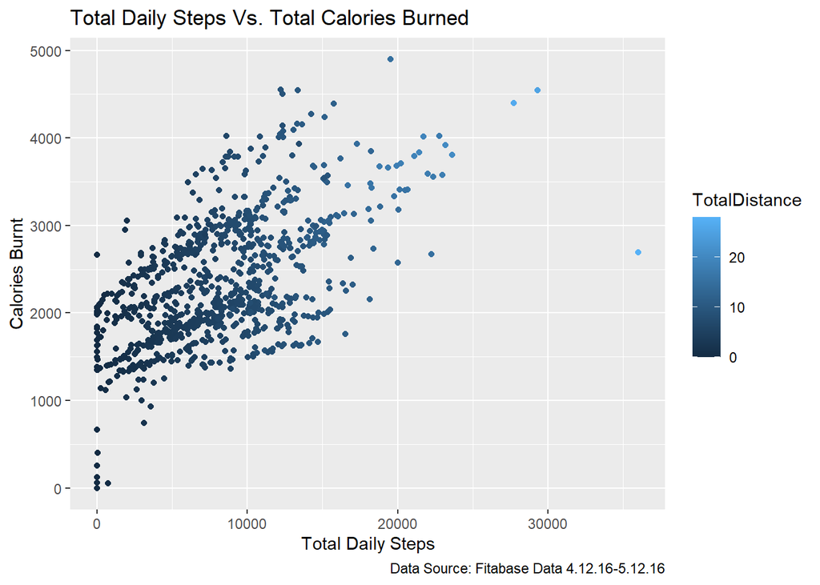

```r
ggplot(data= dailyActivity)+
  geom_point(mapping=aes(x=TotalSteps, y=Calories, color=TotalDistance))+
  labs(title= "Total Daily Steps Vs. Total Calories Burned", caption= 'Data Source: Fitabase Data 4.12.16-5.12.16')+
  xlab("Total Daily Steps") +
  ylab("Calories Burnt")
```

This shows a linear correlation between Total Steps taken and Calories burnt off. That means, the more steps the users take, the more Calories they burn off.

**2. The Relationship between the Minutes minutes spent by the users in a day.**

Summarizing the needed Activity data to get a sum of each category:

```r
Sum_mins<- summarize(dailyActivity, sum_very <- sum(VeryActiveMinutes), sum_fairly <- sum(FairlyActiveMinutes), sum_lightly <-sum(LightlyActiveMinutes), sum_sed <- sum(SedentaryMinutes))
Sum_mins
```

```
##   sum_very <- sum(VeryActiveMinutes) sum_fairly <- sum(FairlyActiveMinutes)
## 1                              19895                                  12751
##   sum_lightly <- sum(LightlyActiveMinutes) sum_sed <- sum(SedentaryMinutes)
## 1                                   181244                           931738
```

Assigning a data frame to store the sums and labels for each sum:

```r
Sum_min_labels <- c('VeryActiveMins', 'FairlyActiveMins', 'LightlyActiveMins', 'SedentaryMins')
Sum_minutes<- c(19895, 12751, 181244, 931738)
Mins_df <- data.frame(group = Sum_min_labels, value=  Sum_minutes)
Mins_df
```

```
##               group  value
## 1    VeryActiveMins  19895
## 2  FairlyActiveMins  12751
## 3 LightlyActiveMins 181244
## 4     SedentaryMins 931738
```

Creating the pie chart using the ggplot2 library:

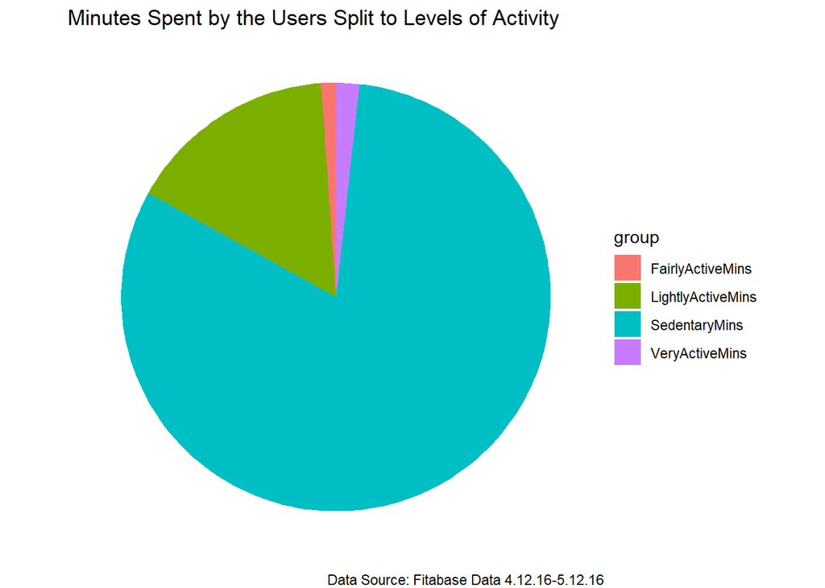

```r
ggplot(Mins_df, aes(x="", y=value, fill=group)) +
  geom_bar(stat="identity", width=1) +
  coord_polar("y", start=0)+
  theme_void()+
   labs(title= "Minutes Spent by the Users Split to Levels of Activity",
      caption= 'Data Source: Fitabase Data 4.12.16-5.12.16')
```

This shows how the participants spent most of their time being sedentary and the active minutes are considerably small compared to the sedentary minutes.

**3. Relationship between Very Active Minutes and Total Daily Calories Burned**  
This code is used to create a scatterplot from the popular package “ggplot”. Calories will be on the y axis and Very Active Minutes will be on the x axis.

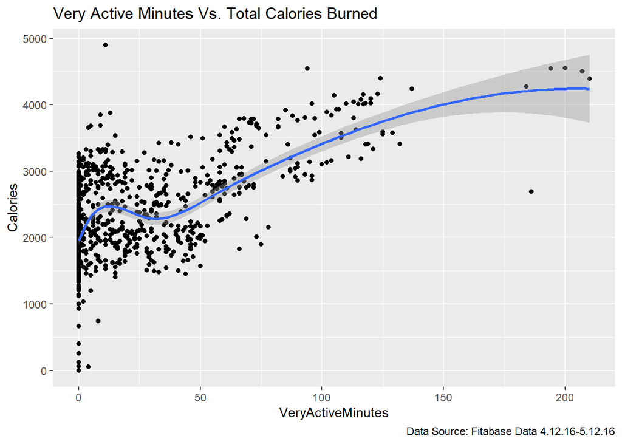

```r
ggplot(data= dailyActivity)+
  geom_point(mapping=aes(x=VeryActiveMinutes, y=Calories))+
  geom_smooth(mapping = aes(x = VeryActiveMinutes, y = Calories))+
  labs(title= "Very Active Minutes Vs. Total Calories Burned", caption= 'Data Source: Fitabase Data 4.12.16-5.12.16')
```

**4. The Relationship Between the time spent asleep in bed Vs time spend awake**

Firstly, we run an SQL query to get the columns: Id, TotalMinutesAsleep and TotalMinutesAwake (which is the total minutes asleep taken away from total minutes in bed):

```r
sleepDay_v2 <- sqldf("SELECT Id, TotalMinutesAsleep, (TotalTimeInBed-TotalMinutesAsleep) AS TotalMinutesAwake FROM sleepDay")

head(sleepDay_v2)
```

```
##           Id TotalMinutesAsleep TotalMinutesAwake
## 1 1503960366                327                19
## 2 1503960366                384                23
## 3 1503960366                412                30
## 4 1503960366                340                27
## 5 1503960366                700                12
## 6 1503960366                304                16
```

Here, we take a the average for each of the 2 columns:

```r
summarize(sleepDay_v2, mean_TotSleep = mean(TotalMinutesAsleep), mean_TotAwake = mean(TotalMinutesAwake))
```

```
##   mean_TotSleep mean_TotAwake
## 1      419.1732      39.30976
```

Now we assign those 2 values and their labels, separately to a data frame:

```r
sleepValues<- c(419.2, 39.3)
sleepLables<- c("TotalMinsAsleep", "TotalMinsAwake")
sleepPie <- data.frame(group= sleepLables, value= sleepValues)
sleepPie
```

```
##             group value
## 1 TotalMinsAsleep 419.2
## 2  TotalMinsAwake  39.3
```

Finally we can create the pie chart using ggplot2:

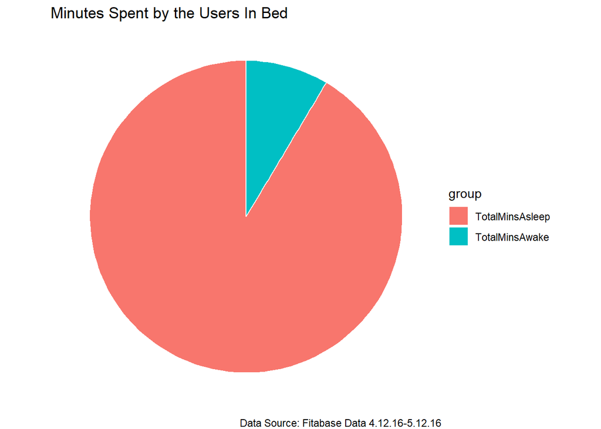

```r
ggplot(sleepPie, aes(x="", y=value, fill=group)) +
  geom_bar(stat="identity", width=1, color="white") +
  coord_polar("y", start=0) +
  theme_void()+
  labs(title= "Minutes Spent by the Users In Bed",
      caption= 'Data Source: Fitabase Data 4.12.16-5.12.16')
```

This plot shows how the users spend a portion of their time in bed awake, when they could have been getting a few more minutes of sleep.

**5. Most Active days in the week**

Here, we add the weekdays to the dailyActivity dataset:

```r
weekday <- weekdays(dailyActivity$ActivityDate)

newdaily_Activity <- data.frame(dailyActivity, weekday)
head(newdaily_Activity)
```

```
##           Id ActivityDate TotalSteps TotalDistance TrackerDistance
## 1 1503960366    4/12/2016      13162           8.5             8.5
## 2 1503960366    4/13/2016      10735           7.0             7.0
## 3 1503960366    4/14/2016      10460           6.7             6.7
## 4 1503960366    4/15/2016       9762           6.3             6.3
## 5 1503960366    4/16/2016      12669           8.2             8.2
## 6 1503960366    4/17/2016       9705           6.5             6.5
##   LoggedActivitiesDistance VeryActiveDistance ModeratelyActiveDistance
## 1                        0                1.9                      0.6
## 2                        0                1.6                      0.7
## 3                        0                2.4                      0.4
## 4                        0                2.1                      1.3
## 5                        0                2.7                      0.4
## 6                        0                3.2                      0.8
##   LightActiveDistance SedentaryActiveDistance VeryActiveMinutes
## 1                 6.1                       0                25
## 2                 4.7                       0                21
## 3                 3.9                       0                30
## 4                 2.8                       0                29
## 5                 5.0                       0                36
## 6                 2.5                       0                38
##   FairlyActiveMinutes LightlyActiveMinutes SedentaryMinutes Calories weekday
## 1                  13                  328              728     1985     Tue
## 2                  19                  217              776     1797     Wed
## 3                  11                  181             1218     1776     Thu
## 4                  34                  209              726     1745     Fri
## 5                  10                  221              773     1863     Sat
## 6                  20                  164              539     1728     Sun
```

Now we create the bar plot using ggplot:

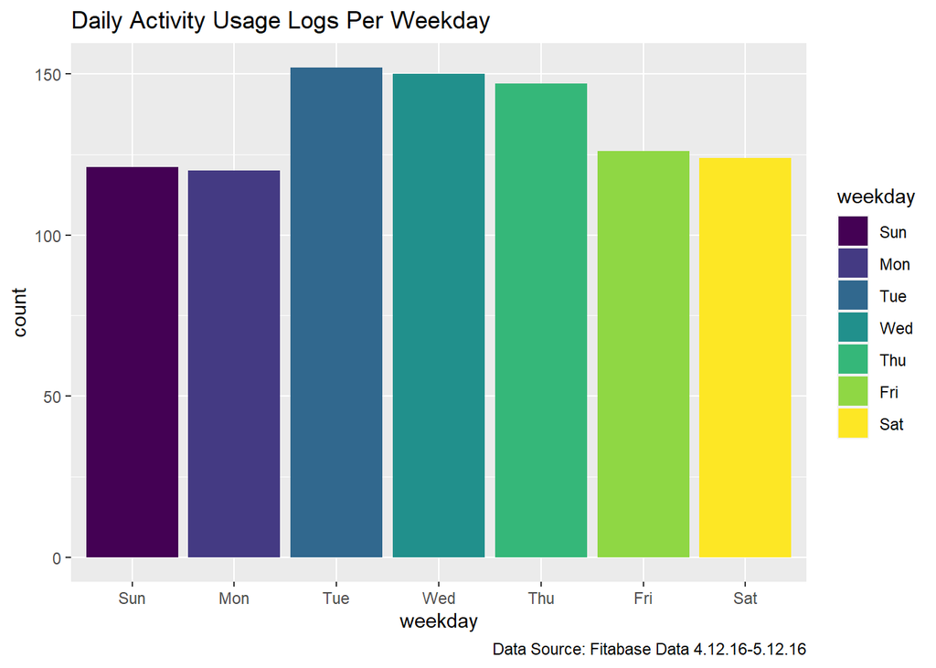

```r
ggplot(data=newdaily_Activity)+
  geom_bar(mapping=aes(x=weekday, fill=weekday))+
  labs(title= "Daily Activity Usage Logs Per Weekday", caption= 'Data Source: Fitabase Data 4.12.16-5.12.16')
```

This barchart clearly shows that the most days that users used the Fitbit is Tuesday, Wednesday and Thursday. Also is least used on Monday.

**6. Total Number of steps taken on days of the week**

First and foremost we run an SQL query to get the sum of the total steps taken per weekday using out previous new_dailyActivity data set:

```r
weekday_Steps<- sqldf("SELECT SUM(TotalSteps) AS SumTotalSteps, weekday FROM newdaily_Activity GROUP BY weekday")
weekday_Steps
```

```
##   SumTotalSteps weekday
## 1        938477     Fri
## 2        933704     Mon
## 3       1010969     Sat
## 4        838921     Sun
## 5       1088658     Thu
## 6       1235001     Tue
## 7       1133906     Wed
```

Now we create a bar-plot using the barplot() function in R:

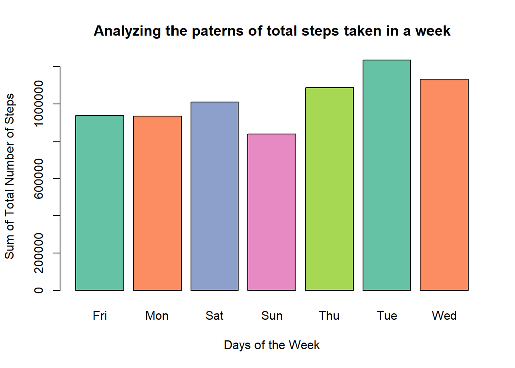

```r
library(RColorBrewer)
coul <- brewer.pal(5, "Set2")
barplot(height=weekday_Steps$SumTotalSteps, names=weekday_Steps$weekday, col=coul, xlab="Days of the Week", ylab="Sum of Total Number of Steps", main="Analyzing the paterns of total steps taken in a week")
```

This shows how Tuesday and Wednesday appears to be the days with higlhest amount of steps whereas Sunday and Monday seem to be the days with the least steps taken.

**7. Realtionship between Average heartrates per day of the week**

Here, we take the days of the week of the heartrate dataset and form a dataframe:

```r
daysoftheweek <- weekdays(heartrate_new$Date)

heartrate_v2 <- data.frame(heartrate_new, daysoftheweek)
head(heartrate_v2)
```

[output not shown]

Now we run an SQL query to find out the average heart rate for each day of the week:

```r
heartrate_query<- sqldf("SELECT AVG(Value) AS Average_Heartrate, daysoftheweek FROM heartrate_v2 GROUP BY daysoftheweek")
heartrate_query
```

```
##   Average_Heartrate daysoftheweek
## 1          75.92500           Fri
## 2          76.45158           Mon
## 3          77.45434           Sat
## 4          77.01372           Sun
## 5          79.97381           Thu
## 6          77.03590           Tue
## 7          77.52084           Wed
```

And finally, we create a bar-plot suing the barplot() function in R:

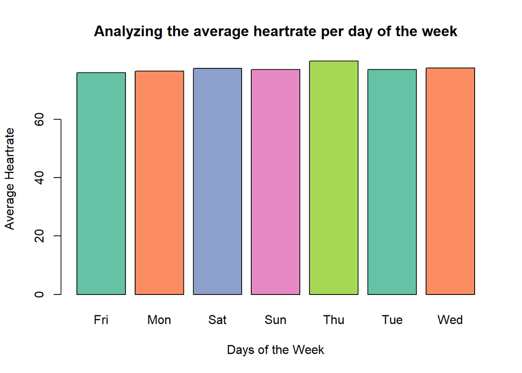

```r
library(RColorBrewer)
coul <- brewer.pal(5, "Set2")
barplot(height=heartrate_query$Average_Heartrate, names=heartrate_query$daysoftheweek, col=coul, xlab="Days of the Week", ylab="Average Heartrate", main="Analyzing the average heartrate per day of the week")
```

### **Act Phase**

#### Recommendations for Bellabeat App

- Unlike the Fitbit, its better also capture the height, age and gender of the user along with the other variables being tracked. This way the app can automatically calculate the BMI of the users and also recommend additional features for women as per their menstrual cycle and their well being.
- There can be notifications alerting the user when its time to sleep after reading information about the time they have to wake up the next day so that the could get the optimum amount of hours of sleep to be on the healthy side.
- The app could also notify the user when they have been sitting (not moving much) for too long so that the user would be encouraged to be active and get some more steps in.
- the app could introduce a way of setting a step goal of around 10,000 steps so that the user gets reports as to how much more they have to move and how much they have traveled, encouraging notification such as “Congratulations! You have reached your step goal for the day!” can be encouraging for users to reach their goal.
- The users can be alerted when their heart rate is getting too high, the app could even provide suggestions as to how to bring the heart rate down to a normal level.
- The regular users of the app who have achieved a certain number of step milestones should be eligible for discount on Bellabeat’s other products such as the Leaf, Time, Spring and other new and upcoming products, that way the user is encouraged to complete their goals more often.
- The women user base can be notified on menstrual heath, tracking their cycle and helpful resources for them to be comfortable throughout their cycle’s journey and be supportive to their needs.
- Make sure that the App takes automatic reading of the tracked variables instead of having the user to enter them manually, this way we can avoid human error and not trouble the users with entering details,
- Sundays seem to be inactive days so we could try to boost the user’s spirit by reminding them of their step goals and maybe facts about benefits upon reaching their step goals for a healthier lifestyle.
- When closing in on the user’s bed time, they should be advised to do lighter activity and relaxing so that they would have an easier time falling asleep. They could be given suggestions to listen to soothing music or to read a book so they can wind-down with much ease.

##### References

- https://r-graph-gallery.com/piechart-ggplot2.html
- https://rpubs.com/jaykesudana/capstone-bellabeat
- https://medium.com/@katherine.larkin/bellabeat-case-study-google-data-analytics-89ccdfe65aa8
- https://www.kaggle.com/code/nahidahsan/google-data-analysis-capstone-project-bellabeat/notebook
- https://www.kaggle.com/code/luisgmolina/case-study-2-luis-garc-a-molina
- https://towardsdev.com/data-analysis-case-study-fitness-tracker-59c522fda4f
- https://www.kaggle.com/code/irenashen1/capstone-bellabeat-case-study-r/notebook

#### *A big thank you for reading my first ever case study results! I hope that you found this interesting. Please leave a comment and upvote if you found this useful!*